# Pertemuan 3 - Regresi dengan Peubah Lag

# Data 1

## Impor Data

```r
data <- data.frame(
  Periode = 1:20,
  Market_share = c(
    3.63, 4.20, 3.33, 4.54, 2.89,
    4.87, 4.90, 5.29, 6.18, 7.20,
    7.25, 6.09, 6.80, 8.65, 8.43,
    8.29, 7.18, 7.90, 8.45, 8.23
  ),
  Price = c(
    0.97, 0.95, 0.99, 0.91, 0.98,
    0.90, 0.89, 0.86, 0.85, 0.82,
    0.79, 0.83, 0.81, 0.77, 0.76,
    0.80, 0.83, 0.79, 0.76, 0.78
  )
)

# Melihat data
data
```

```
##    Periode Market_share Price
## 1        1         3.63  0.97
## 2        2         4.20  0.95
## 3        3         3.33  0.99
## 4        4         4.54  0.91
## 5        5         2.89  0.98
## 6        6         4.87  0.90
## 7        7         4.90  0.89
## 8        8         5.29  0.86
## 9        9         6.18  0.85
## 10      10         7.20  0.82
## 11      11         7.25  0.79
## 12      12         6.09  0.83
## 13      13         6.80  0.81
## 14      14         8.65  0.77
## 15      15         8.43  0.76
## 16      16         8.29  0.80
## 17      17         7.18  0.83
## 18      18         7.90  0.79
## 19      19         8.45  0.76
## 20      20         8.23  0.78
```

```r
data$Xt <- data$Price
data$Yt <- data$Market_share
```

```r
head(data)
```

```
##   Periode Market_share Price   Xt   Yt
## 1       1         3.63  0.97 0.97 3.63
## 2       2         4.20  0.95 0.95 4.20
## 3       3         3.33  0.99 0.99 3.33
## 4       4         4.54  0.91 0.91 4.54
## 5       5         2.89  0.98 0.98 2.89
## 6       6         4.87  0.90 0.90 4.87
```

## Pembagian Data

```r
#SPLIT DATA
train<-data[1:15,]
test<-data[16:20,]
```

```r
#data time series
train.ts<-ts(train)
test.ts<-ts(test)
data.ts<-ts(data)
```

[figure not shown]

- **distributed lag model** : Variabel Dependen Y dipengaruhi oleh lag dari variabel independen X ( Xt-1, Xt-2 , dst)
- **Autoregresive model** : Variabel Dependen Y dipengaruhi oleh lag dirinya sendiri (Yt-1, Yt-2, dst) dan X sekarang (Xt)

## Model Koyck

Model Koyck didasarkan pada asumsi bahwa semakin jauh jarak lag peubah independen dari periode sekarang maka semakin kecil pengaruh peubah lag terhadap peubah dependen.

Koyck mengusulkan suatu metode untuk menduga model dinamis distributed lag dengan mengasumsikan bahwa semua koefisien $\beta$ mempunyai tanda sama.

Model kyock merupakan jenis paling umum dari model infinite distributed lag dan juga dikenal sebagai geometric lag

$$y_t=a(1-\lambda)+\beta_0X_t+\beta_1Z_t+\lambda Y_{t-1}+V_t$$

dengan
$$V_t=u_t-\lambda
u_{t-1}$$

### Pemodelan

Pemodelan model Koyck dengan `R` dapat menggunakan `dLagM::koyckDlm()` . Fungsi umum dari `koyckDlm` adalah sebagai berikut.

```r
koyckDlm(x , y , intercept)
```

Fungsi `koyckDlm()` akan menerapkan model lag terdistribusi dengan transformasi Koyck satu prediktor. Nilai `x` dan `y` tidak perlu sebagai objek *time series* (`ts`). `intercept` dapat dibuat `TRUE` untuk memasukkan intersep ke dalam model.

```r
#MODEL KOYCK
model.koyck <- koyckDlm(x = train$Xt, y = train$Yt)
summary(model.koyck)
```

```
##
## Call:
## "Y ~ (Intercept) + Y.1 + X.t"
##
## Residuals:
##     Min      1Q  Median      3Q     Max
## -0.9997 -0.3171  0.0652  0.2586  1.1063
##
## Coefficients:
##             Estimate Std. Error t value Pr(>|t|)
## (Intercept)  15.4328    14.7611   1.046    0.318
## Y.1           0.3651     0.5152   0.709    0.493
## X.t         -13.4703    13.8869  -0.970    0.353
##
## Residual standard error: 0.599 on 11 degrees of freedom
## Multiple R-Squared: 0.9037,  Adjusted R-squared: 0.8861
## Wald test: 37.92 on 2 and 11 DF,  p-value: 1.16e-05
##
## Diagnostic tests:
## NULL
##
##                             alpha      beta       phi
## Geometric coefficients:  24.30938 -13.47028 0.3651498
```

```r
AIC(model.koyck)
```

```
## [1] 30.00231
```

```r
BIC(model.koyck)
```

```
## [1] 32.55853
```

Dari hasil tersebut, didapat bahwa peubah $x_t$ dan $y_{t-1}$ memiliki nilai $P-Value>0.05$. Hal ini menunjukkan bahwa peubah $x_t$ dan $y_{t-1}$ tidak berpengaruh signifikan terhadap $y$. Adapun model keseluruhannya adalah sebagai berikut

$$\hat{Y_t}=15.4328-13.4703X_t+0.3651Y_{t-1}$$

### Peramalan dan Akurasi

Berikut adalah hasil peramalan y untuk 5 periode kedepan menggunakan model koyck

```r
fore.koyck <- forecast(model = model.koyck, x=test$Xt, h=5)
fore.koyck
```

```
## $forecasts
## [1] 7.734805 7.076847 7.375405 7.888531 7.806494
##
## $call
## forecast.koyckDlm(model = model.koyck, x = test$Xt, h = 5)
##
## attr(,"class")
## [1] "forecast.koyckDlm" "dLagM"
```

```r
mape.koyck <- MAPE(fore.koyck$forecasts, test$Yt)
mape.koyck #data test
```

```
## [1] 0.05312954
```

```r
#akurasi data training
GoF(model.koyck)
```

```
##              n       MAE         MPE       MAPE      sMAPE      MASE       MSE
## model.koyck 14 0.4215632 -0.01898878 0.08448088 0.08112884 0.4555545 0.2818772
##                 MRAE     GMRAE
## model.koyck 1.457091 0.5463437
```

## Regression with Distributed Lag

Pemodelan model Regression with Distributed Lag dengan `R` dapat menggunakan `dLagM::dlm()` . Fungsi umum dari `dlm` adalah sebagai berikut.

```r
dlm(formula , data , x , y , q , remove )
```

Fungsi `dlm()` akan menerapkan model lag terdistribusi dengan satu atau lebih prediktor. Nilai `x` dan `y` tidak perlu sebagai objek *time series* (`ts`). $q$ adalah integer yang mewakili panjang *lag* yang terbatas.

### Pemodelan (Lag=2)

```r
model.dlm <- dlm(x = train$Xt,y = train$Yt , q = 2)
summary(model.dlm)
```

```
##
## Call:
## lm(formula = model.formula, data = design)
##
## Residuals:
##      Min       1Q   Median       3Q      Max
## -0.55526 -0.24858 -0.08971  0.20176  0.65633
##
## Coefficients:
##              Estimate Std. Error t value Pr(>|t|)
## (Intercept)  26.29549    1.69541  15.510 8.44e-08 ***
## x.t         -24.13651    4.05335  -5.955 0.000214 ***
## x.1          -0.00163    3.20631  -0.001 0.999606
## x.2           0.34290    4.21417   0.081 0.936929
## ---
## Signif. codes:  0 '***' 0.001 '**' 0.01 '*' 0.05 '.' 0.1 ' ' 1
##
## Residual standard error: 0.4366 on 9 degrees of freedom
## Multiple R-squared:  0.9553, Adjusted R-squared:  0.9404
## F-statistic: 64.06 on 3 and 9 DF,  p-value: 2.151e-06
##
## AIC and BIC values for the model:
##        AIC     BIC
## 1 20.56206 23.3868
```

```r
AIC(model.dlm)
```

```
## [1] 20.56206
```

```r
BIC(model.dlm)
```

```
## [1] 23.3868
```

Dari hasil diatas, didapat bahwa $P-value$ dari intercept dan $x_{t}<0.05$. Hal ini menunjukkan bahwa intercept dan $x_{t}$ berpengaruh signifikan terhadap $y$. Adapun model keseluruhan yang terbentuk adalah sebagai berikut

$$\hat{Y_t}=26.29549-24.13651X_t-0.00163X_{t-1}+0.34290X_{t-2}$$

### Peramalan dan Akurasi

Berikut merupakan hasil peramalan $y$ untuk 5 periode kedepan

```r
fore.dlm <- forecast(model = model.dlm, x=test$Xt, h=5)
fore.dlm
```

```
## $forecasts
## [1] 7.249082 6.521493 7.500621 8.235068 7.738671
##
## $call
## forecast.dlm(model = model.dlm, x = test$Xt, h = 5)
##
## attr(,"class")
## [1] "forecast.dlm" "dLagM"
```

```r
mape.dlm <- MAPE(fore.dlm$forecasts, test$Yt)
mape.dlm
```

```
## [1] 0.0705934
```

```r
#akurasi data training
GoF(model.dlm)
```

```
##            n       MAE           MPE       MAPE      sMAPE      MASE       MSE
## model.dlm 13 0.3009786 -0.0004896023 0.05451787 0.05541524 0.3236329 0.1319396
##               MRAE     GMRAE
## model.dlm 1.474088 0.3515233
```

### *Lag* Optimum

```r
#penentuan lag optimum
finiteDLMauto(formula = Yt ~ Xt,
              data = data.frame(train), q.min = 1, q.max = 10,
              model.type = "dlm", error.type = "AIC", trace = TRUE)
```

```
##    q - k    MASE      AIC      BIC   GMRAE    MBRAE R.Adj.Sq  Ljung-Box
## 7      7 0.00000     -Inf     -Inf 0.00000  0.00000      NaN        NaN
## 8      8 0.00000     -Inf     -Inf 0.00000  0.00000      NaN        NaN
## 9      9 0.00000     -Inf     -Inf 0.00000  0.00000      NaN        NaN
## 10    10 0.00000     -Inf     -Inf 0.00000  0.00000      NaN        NaN
## 6      6 0.08453 -4.06421 -2.28919 0.11903 -0.33129  0.97249 0.04562035
## 3      3 0.27946 14.41990 17.32934 0.49694 -0.34334  0.95685 0.87839563
## 5      5 0.30204 15.91911 18.33979 0.49375 -0.33012  0.89375 0.34730411
## 4      4 0.29388 16.21356 18.99882 0.48458 -0.05971  0.94508 0.68007694
## 1      1 0.35387 19.92429 22.48052 0.47815  1.13162  0.94457 0.32743011
## 2      2 0.32363 20.56206 23.38680 0.35152 -0.40855  0.94035 0.68818708
```

Berdasarkan output tersebut, lag optimum didapatkan ketika lag=6. Selanjutnya dilakukan pemodelan untuk lag=6

```r
#model dlm dengan lag optimum
model.dlm2 <- dlm(x = train$Xt,y = train$Yt , q = 6)
summary(model.dlm2)
```

```
##
## Call:
## lm(formula = model.formula, data = design)
##
## Residuals:
##        1        2        3        4        5        6        7        8
## -0.06257  0.05379  0.06679 -0.05236 -0.03731  0.04871 -0.07404  0.12979
##        9
## -0.07279
##
## Coefficients:
##             Estimate Std. Error t value Pr(>|t|)
## (Intercept)  37.4332     2.7496  13.614   0.0467 *
## x.t         -43.9959     5.1527  -8.538   0.0742 .
## x.1           1.3336     4.4868   0.297   0.8161
## x.2           0.6599     2.9610   0.223   0.8604
## x.3           0.3176     3.5214   0.090   0.9427
## x.4          16.6181     5.4842   3.030   0.2029
## x.5           1.3711     3.0017   0.457   0.7272
## x.6         -13.6131     4.2894  -3.174   0.1943
## ---
## Signif. codes:  0 '***' 0.001 '**' 0.01 '*' 0.05 '.' 0.1 ' ' 1
##
## Residual standard error: 0.2131 on 1 degrees of freedom
## Multiple R-squared:  0.9966, Adjusted R-squared:  0.9725
## F-statistic:  41.4 on 7 and 1 DF,  p-value: 0.1191
##
## AIC and BIC values for the model:
##         AIC       BIC
## 1 -4.064207 -2.289185
```

```r
AIC(model.dlm2)
```

```
## [1] -4.064207
```

```r
BIC(model.dlm2)
```

```
## [1] -2.289185
```

Dari hasil tersebut terdapat beberapa peubah yang berpengaruh signifikan terhadap taraf nyata 5% yaitu Intercept, terhadap taraf 10% yaitu $x_t$. Adapun keseluruhan model yang terbentuk adalah

$$\hat{Y_t}=37.4332-43.9959X_t+...-13.6131X_{t-6}$$

Adapun hasil peramalan 5 periode kedepan menggunakan model tersebut adalah sebagai berikut

```r
#peramalan dan akurasi
fore.dlm2 <- forecast(model = model.dlm2, x=test$Xt, h=5)

#akurasi data test
mape.dlm2<- MAPE(fore.dlm2$forecasts, test$Yt)
mape.dlm2
```

```
## [1] 0.06368703
```

```r
#akurasi data training
GoF(model.dlm2)
```

```
##            n        MAE           MPE        MAPE       sMAPE       MASE
## model.dlm2 9 0.06646092 -8.151672e-05 0.009854368 0.009858763 0.08452899
##                    MSE      MRAE     GMRAE
## model.dlm2 0.005044506 0.1947309 0.1190314
```

## Model Autoregressive

Peubah dependen dipengaruhi oleh peubah independen pada waktu sekarang, serta dipengaruhi juga oleh peubah dependen itu sendiri pada satu waktu yang lalu maka model tersebut disebut *autoregressive* (Gujarati 2004).

### Pemodelan

Pemodelan Autoregressive dilakukan menggunakan fungsi `dLagM::ardlDlm()` . Fungsi tersebut akan menerapkan *autoregressive* berordo $(p,q)$ dengan satu prediktor. Fungsi umum dari `ardlDlm()` adalah sebagai berikut.

```r
ardlDlm(formula = NULL , data = NULL , x = NULL , y = NULL , p = 1 , q = 1 ,
         remove = NULL )
```

Dengan $p$ adalah integer yang mewakili panjang *lag* yang terbatas dan $q$ adalah integer yang merepresentasikan ordo dari proses *autoregressive*.

```r
model.ardl <- ardlDlm(x = train$Xt, y = train$Yt, p = 1 , q = 1)
summary(model.ardl)
```

```
##
## Time series regression with "ts" data:
## Start = 2, End = 15
##
## Call:
## dynlm(formula = as.formula(model.text), data = data, start = 1)
##
## Residuals:
##      Min       1Q   Median       3Q      Max
## -0.50247 -0.30360 -0.05952  0.31335  0.74004
##
## Coefficients:
##             Estimate Std. Error t value Pr(>|t|)
## (Intercept)  18.1366     7.7391   2.344   0.0411 *
## X.t         -23.5593     2.8404  -8.294 8.57e-06 ***
## X.1           7.2280     7.2307   1.000   0.3411
## Y.1           0.3028     0.3013   1.005   0.3386
## ---
## Signif. codes:  0 '***' 0.001 '**' 0.01 '*' 0.05 '.' 0.1 ' ' 1
##
## Residual standard error: 0.4177 on 10 degrees of freedom
## Multiple R-squared:  0.9574, Adjusted R-squared:  0.9446
## F-statistic: 74.91 on 3 and 10 DF,  p-value: 3.731e-07
```

```r
AIC(model.ardl)
```

```
## [1] 20.5772
```

```r
BIC(model.ardl)
```

```
## [1] 23.77248
```

```r
model.ardl <- ardlDlm(formula = Yt ~ Xt,
                         data = train,p = 1 , q = 1)
summary(model.ardl)
```

```
##
## Time series regression with "ts" data:
## Start = 2, End = 15
##
## Call:
## dynlm(formula = as.formula(model.text), data = data)
##
## Residuals:
##      Min       1Q   Median       3Q      Max
## -0.50247 -0.30360 -0.05952  0.31335  0.74004
##
## Coefficients:
##             Estimate Std. Error t value Pr(>|t|)
## (Intercept)  18.1366     7.7391   2.344   0.0411 *
## Xt.t        -23.5593     2.8404  -8.294 8.57e-06 ***
## Xt.1          7.2280     7.2307   1.000   0.3411
## Yt.1          0.3028     0.3013   1.005   0.3386
## ---
## Signif. codes:  0 '***' 0.001 '**' 0.01 '*' 0.05 '.' 0.1 ' ' 1
##
## Residual standard error: 0.4177 on 10 degrees of freedom
## Multiple R-squared:  0.9574, Adjusted R-squared:  0.9446
## F-statistic: 74.91 on 3 and 10 DF,  p-value: 3.731e-07
```

```r
AIC(model.ardl)
```

```
## [1] 20.5772
```

```r
BIC(model.ardl)
```

```
## [1] 23.77248
```

Hasil di atas menunjukkan bahwa selain peubah $x_{t}$, hasil uji t menunjukkan nilai-p pada peubah $\ge0.05$ Hal ini menunjukkan bahwa peubah $x_{t}$ berpengaruh signifikan terhadap $y_t$, sementara $x_{t-1}$ dan $y_{t-1}$ tidak berpengaruh signifikan terhadap $y_t$. Model keseluruhannya adalah sebagai berikut:

$$\hat{Y}=18.1366-23.5593X_t+7.2280X_{t-1}+0.3028_{t-1}$$

### Peramalan dan Akurasi

```r
fore.ardl <- forecast(model = model.ardl, x=test$Xt, h=5)
fore.ardl
```

```
## $forecasts
## [1] 7.335421 6.586277 7.518614 8.218625 7.742593
##
## $call
## forecast.ardlDlm(model = model.ardl, x = test$Xt, h = 5)
##
## attr(,"class")
## [1] "forecast.ardlDlm" "dLagM"
```

Data di atas merupakan hasil peramalan untuk 5 periode ke depan menggunakan Model Autoregressive dengan $p=1$ dan $q=1$.

```r
mape.ardl <- MAPE(fore.ardl$forecasts, test$Yt)
mape.ardl
```

```
## [1] 0.0665442
```

```r
#akurasi data training
GoF(model.ardl)
```

```
##             n       MAE          MPE       MAPE      sMAPE      MASE       MSE
## model.ardl 14 0.2976341 -0.001431049 0.05455596 0.05483419 0.3216328 0.1246353
##                MRAE     GMRAE
## model.ardl 1.506877 0.3398952
```

Berdasarkan akurasi di atas, terlihat bahwa nilai MAPE keduanya tidak jauh berbeda. Artinya, model regresi dengan distribusi lag ini tidak `overfitted` atau `underfitted`

### *Lag* Optimum

```r
#penentuan lag optimum
model.ardl.opt <- ardlBoundOrders(data = data.frame(data), ic = "AIC",
                                  formula = Yt ~ Xt )
model.ardl.opt
```

```
## $p
##   Xt
## 1  4
##
## $q
## [1] 5
##
## $Stat.table
##           q = 1     q = 2     q = 3     q = 4     q = 5     q = 6 q = 7 q = 8
## p = 1 26.443222 25.585928  27.90404  28.15440  15.86472  12.16060    NA    NA
## p = 2 25.284828 27.280557  29.39566  28.28302 -12.95797 -20.41095    NA    NA
## p = 3 29.665001 29.665001  29.54627  29.21222 -11.13376        NA    NA    NA
## p = 4 28.638892 29.730704  29.73070  25.21244 -34.02031        NA    NA    NA
## p = 5  9.600496 -1.718359 -18.02940 -18.02940        NA        NA    NA    NA
## p = 6 17.113404        NA        NA        NA        NA        NA    NA    NA
##       q = 9 q = 10 q = 11 q = 12 q = 13 q = 14 q = 15
## p = 1    NA     NA     NA     NA     NA     NA     NA
## p = 2    NA     NA     NA     NA     NA     NA     NA
## p = 3    NA     NA     NA     NA     NA     NA     NA
## p = 4    NA     NA     NA     NA     NA     NA     NA
## p = 5    NA     NA     NA     NA     NA     NA     NA
## p = 6    NA     NA     NA     NA     NA     NA     NA
##
## $min.Stat
## [1] -34.02031
```

```r
# Mencari posisi nilai AIC minimum
pos <- which(
  model.ardl.opt$Stat.table ==
    min(model.ardl.opt$Stat.table, na.rm = TRUE),
  arr.ind = TRUE
)

# Ambil p dan q optimum
p_opt <- pos[1, "row"]
q_opt <- pos[1, "col"]

# Tampilkan hasil
data.frame(
  p_optimum = p_opt,
  q_optimum = q_opt,
  AIC = model.ardl.opt$min.Stat
)
```

```
##   p_optimum q_optimum       AIC
## 1         4         5 -34.02031
```

Dari tabel di atas, dapat terlihat bahwa nilai AIC terendah didapat ketika $p=4$ dan $q=5$, yaitu sebesar `-34.02031`. Artinya, model autoregressive optimum didapat ketika $p=4$ dan $q=5$.

Selanjutnya dapat dilakukan pemodelan dengan nilai $p$ dan $q$ optimum seperti inisialisasi di langkah sebelumnya.

## Perbandingan Model

Membuat tabel ringkas akurasi model berdasarkan nilai MAPE (Mean Absolute Percentage Error).

```r
akurasi <- matrix(c(mape.koyck, mape.dlm, mape.dlm2, mape.ardl))
row.names(akurasi)<- c("Koyck","DLM 1","DLM 2","Autoregressive")
colnames(akurasi) <- c("MAPE")
akurasi
```

```
##                      MAPE
## Koyck          0.05312954
## DLM 1          0.07059340
## DLM 2          0.06368703
## Autoregressive 0.06654420
```

Berdasarkan nilai MAPE, model paling optimum didapat pada Model Koyck karena memiliki nilai MAPE yang terkecil.

### Plot

Untuk membandingkan hasil peramalan dari berbagai model (Koyck, DLM 1, DLM 2, dan ARDL) dengan data aktual, dibuat grafik garis. Visualisasi ini membantu melihat seberapa dekat hasil ramalan tiap model dengan nilai aktual.

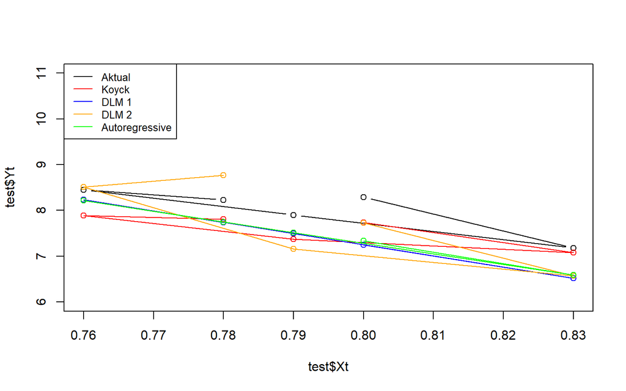

```r
par(mfrow=c(1,1))  # atur layout grafik tunggal

# plot data aktual
plot(test$Xt, test$Yt, type="b", col="black", ylim=c(6,11))

# tambahkan garis ramalan dari masing-masing model
points(test$Xt, fore.koyck$forecasts, col="red");   lines(test$Xt, fore.koyck$forecasts, col="red")
points(test$Xt, fore.dlm$forecasts, col="blue");    lines(test$Xt, fore.dlm$forecasts, col="blue")
points(test$Xt, fore.dlm2$forecasts, col="orange"); lines(test$Xt, fore.dlm2$forecasts, col="orange")
points(test$Xt, fore.ardl$forecasts, col="green");  lines(test$Xt, fore.ardl$forecasts, col="green")

# legenda model
legend("topleft",
       c("Aktual", "Koyck","DLM 1","DLM 2", "Autoregressive"),
       lty=1, col=c("black","red","blue","orange","green"), cex=0.8)
```

# Data 2

## Impor Data

```r
data <- data.frame(
  Year = 1975:2014,
  Sales = c(
    11.7, 12.0, 12.3, 12.8, 13.1,
    13.6, 13.9, 14.4, 14.7, 15.3,
    15.5, 15.8, 16.1, 16.6, 16.9,
    16.7, 16.9, 17.4, 17.6, 17.9,
    18.0, 17.9, 18.0, 18.2, 18.2,
    18.3, 18.6, 19.2, 19.3, 19.5,
    19.2, 19.3, 19.5, 20.0, 20.0,
    19.9, 19.8, 19.9, 20.2, 21.0
  ),
  Advertising = c(
    9.4, 9.6, 10.0, 10.4, 10.8,
    10.9, 11.7, 12.2, 12.5, 12.9,
    13.0, 13.2, 13.8, 14.2, 14.6,
    14.4, 15.0, 15.4, 15.7, 15.9,
    15.9, 16.0, 16.3, 16.2, 16.8,
    17.3, 17.6, 18.1, 18.3, 18.5,
    18.7, 18.9, 19.2, 20.0, 20.0,
    20.3, 20.4, 21.0, 21.5, 22.1
  )
)

data
```

```
##    Year Sales Advertising
## 1  1975  11.7         9.4
## 2  1976  12.0         9.6
## 3  1977  12.3        10.0
## 4  1978  12.8        10.4
## 5  1979  13.1        10.8
## 6  1980  13.6        10.9
## 7  1981  13.9        11.7
## 8  1982  14.4        12.2
## 9  1983  14.7        12.5
## 10 1984  15.3        12.9
## 11 1985  15.5        13.0
## 12 1986  15.8        13.2
## 13 1987  16.1        13.8
## 14 1988  16.6        14.2
```

[output cut: 26 more lines]

```r
data$Xt <- data$Advertising
data$Yt <- data$Sales
```

```r
head(data)
```

```
##   Year Sales Advertising   Xt   Yt
## 1 1975  11.7         9.4  9.4 11.7
## 2 1976  12.0         9.6  9.6 12.0
## 3 1977  12.3        10.0 10.0 12.3
## 4 1978  12.8        10.4 10.4 12.8
## 5 1979  13.1        10.8 10.8 13.1
## 6 1980  13.6        10.9 10.9 13.6
```

## Pembagian Data

```r
#SPLIT DATA
train<-data[1:32,]
test<-data[33:40,]
```

```r
#data time series
train.ts<-ts(train)
test.ts<-ts(test)
data.ts<-ts(data)
```

## Model Autoregressive

### Pemodelan

```r
ardlDlm(formula = NULL , data = NULL , x = NULL , y = NULL , p = 1 , q = 1 ,
         remove = NULL )
```

Dengan $p$ adalah integer yang mewakili panjang *lag* yang terbatas dan $q$ adalah integer yang merepresentasikan ordo dari proses *autoregressive*.

```r
model.ardl <- ardlDlm(x = train$Xt, y = train$Yt, p = 1 , q = 1)
summary(model.ardl)
```

```
##
## Time series regression with "ts" data:
## Start = 2, End = 32
##
## Call:
## dynlm(formula = as.formula(model.text), data = data, start = 1)
##
## Residuals:
##      Min       1Q   Median       3Q      Max
## -0.42212 -0.13934  0.00585  0.09313  0.33270
##
## Coefficients:
##             Estimate Std. Error t value Pr(>|t|)
## (Intercept)  1.30304    0.47500   2.743   0.0107 *
## X.t          0.30844    0.15564   1.982   0.0578 .
## X.1         -0.20644    0.17382  -1.188   0.2453
## Y.1          0.83951    0.09995   8.399  5.2e-09 ***
## ---
## Signif. codes:  0 '***' 0.001 '**' 0.01 '*' 0.05 '.' 0.1 ' ' 1
##
## Residual standard error: 0.1791 on 27 degrees of freedom
## Multiple R-squared:  0.9943, Adjusted R-squared:  0.9937
## F-statistic:  1575 on 3 and 27 DF,  p-value: < 2.2e-16
```

```r
AIC(model.ardl)
```

```
## [1] -12.93737
```

```r
BIC(model.ardl)
```

```
## [1] -5.767436
```

```r
model.ardl <- ardlDlm(formula = Yt ~ Xt,
                         data = train,p = 1 , q = 1)
summary(model.ardl)
```

```
##
## Time series regression with "ts" data:
## Start = 2, End = 32
##
## Call:
## dynlm(formula = as.formula(model.text), data = data)
##
## Residuals:
##      Min       1Q   Median       3Q      Max
## -0.42212 -0.13934  0.00585  0.09313  0.33270
##
## Coefficients:
##             Estimate Std. Error t value Pr(>|t|)
## (Intercept)  1.30304    0.47500   2.743   0.0107 *
## Xt.t         0.30844    0.15564   1.982   0.0578 .
## Xt.1        -0.20644    0.17382  -1.188   0.2453
## Yt.1         0.83951    0.09995   8.399  5.2e-09 ***
## ---
## Signif. codes:  0 '***' 0.001 '**' 0.01 '*' 0.05 '.' 0.1 ' ' 1
##
## Residual standard error: 0.1791 on 27 degrees of freedom
## Multiple R-squared:  0.9943, Adjusted R-squared:  0.9937
## F-statistic:  1575 on 3 and 27 DF,  p-value: < 2.2e-16
```

```r
AIC(model.ardl)
```

```
## [1] -12.93737
```

```r
BIC(model.ardl)
```

```
## [1] -5.767436
```

$$\hat{Y}=1.30304+0.30844X_t-0.20644X_{t-1}+0.83951Y_{t-1}$$

### Peramalan dan Akurasi

```r
fore.ardl <- forecast(model = model.ardl, x=test$Xt, h=8)
fore.ardl
```

```
## $forecasts
## [1] 19.52586 19.90030 20.04949 20.26727 20.41900 20.71081 20.98614 21.29912
##
## $call
## forecast.ardlDlm(model = model.ardl, x = test$Xt, h = 8)
##
## attr(,"class")
## [1] "forecast.ardlDlm" "dLagM"
```

Data di atas merupakan hasil peramalan untuk 8 periode ke depan menggunakan Model Autoregressive dengan $p=1$ dan $q=1$.

```r
mape.ardl <- MAPE(fore.ardl$forecasts, test$Yt)
mape.ardl
```

```
## [1] 0.01905123
```

```r
#akurasi data training
GoF(model.ardl)
```

```
##             n       MAE          MPE        MAPE       sMAPE      MASE
## model.ardl 31 0.1351188 -0.000172352 0.008225628 0.008223183 0.4768899
##                   MSE     MRAE     GMRAE
## model.ardl 0.02793731 73180231 0.7094915
```

### *Lag* Optimum

```r
#penentuan lag optimum
model.ardl.opt <- ardlBoundOrders(data = data.frame(data), ic = "AIC",
                                  formula = Yt ~ Xt )
model.ardl.opt
```

```
## $p
##   Xt
## 1  4
##
## $q
## [1] 15
##
## $Stat.table
##             q = 1      q = 2      q = 3       q = 4        q = 5      q = 6
## p = 1  -15.008746 -11.952031 -11.702811 -10.4556102   -7.4743459 -10.190508
## p = 2  -13.773954 -12.129560 -11.273832  -9.7873186   -6.6233481  -8.740430
## p = 3   -8.848612  -8.848612 -12.443867 -10.3937201   -7.1398397  -9.693082
## p = 4  -12.022451 -10.663941 -10.663941  -8.6692457   -5.3883982  -8.000189
## p = 5   -6.455663  -4.517684  -6.129877  -6.1298773   -5.8218760  -9.506366
## p = 6  -11.513095  -9.679368 -10.603965  -8.7469140   -8.7469140  -8.630625
## p = 7   -5.508868  -3.728014  -6.010216  -4.5325635  -12.0788009 -12.078801
## p = 8   -8.927789  -7.599283  -5.788882  -4.6394213  -11.9646171 -10.910332
## p = 9   -5.602665  -3.769155  -2.219895  -0.2595925   -9.1716507  -7.295497
## p = 10  -9.465550  -7.587108  -5.720971  -3.8196288   -8.1361157  -6.288259
## p = 11   1.701332   2.523049   3.963660   5.8214473   -0.1570961   1.564017
## p = 12  -6.976292  -6.760264  -4.921983  -7.0600636   -9.0408197  -8.605279
## p = 13  -1.534882  -4.200569  -6.944121  -5.0254590  -32.2884029 -46.908793
## p = 14  -3.660390  -1.761109  -2.219038  -3.7538496 -198.9302277         NA
## p = 15 -11.707853 -17.884028 -17.585602          NA           NA         NA
##             q = 7      q = 8        q = 9      q = 10       q = 11     q = 12
## p = 1   -7.624070  -8.686449   -4.7462387 -3.32746110   -2.9869318 -0.9555962
## p = 2   -5.806960  -7.921509   -4.2989938 -2.59233785   -1.1348530  0.3798720
## p = 3   -6.091044  -7.142078   -4.2143900 -1.64141900   -0.2764654  2.0637751
## p = 4   -4.274001  -5.164970   -2.2163924 -0.02517076    0.1775901  3.0432639
## p = 5   -5.454353  -5.301255   -1.9990132  0.94455082    1.2370098  2.5673773
## p = 6   -4.511772  -3.986967   -0.7254173  2.14054832    2.0257425  0.1204914
## p = 7  -13.506180 -11.580354   -7.7220728 -3.84200566   -3.0518769 -4.1223494
## p = 8  -10.910332  -9.645933   -5.8154895 -2.15509138   -2.0247232 -3.0170743
## p = 9   -6.993088  -6.993088   -5.9083235 -2.05781567   -0.3245455 -1.0178440
## p = 10  -7.323609  -8.441982   -8.4419817 -8.92421877   -7.3319735 -5.7824865
## p = 11  -1.509374  -6.042816   -9.7853072 -9.78530724 -121.6529036         NA
## p = 12  -6.819227 -19.795453 -125.1056421          NA           NA         NA
## p = 13 -93.617891         NA           NA          NA           NA         NA
## p = 14         NA         NA           NA          NA           NA         NA
## p = 15         NA         NA           NA          NA           NA         NA
##            q = 13     q = 14     q = 15
## p = 1    2.983211   2.566813  -17.54638
## p = 2    3.581183   4.065066  -76.93283
## p = 3    5.505343   5.691237  -97.73207
## p = 4    6.600634   6.567285 -305.75496
## p = 5    5.541829  -6.747419         NA
## p = 6   -4.715695 -94.241328         NA
## p = 7  -42.546289         NA         NA
## p = 8  -47.628148         NA         NA
## p = 9          NA         NA         NA
## p = 10         NA         NA         NA
## p = 11         NA         NA         NA
## p = 12         NA         NA         NA
## p = 13         NA         NA         NA
## p = 14         NA         NA         NA
## p = 15         NA         NA         NA
##
## $min.Stat
## [1] -305.755
```

```r
min_q <- c()

for(i in 1:6){
  min_q[i] <- min(model.ardl.opt$Stat.table[[i]], na.rm = TRUE)
}

q_opt <- which(min_q == min(min_q, na.rm = TRUE))

p_opt <- which(
  model.ardl.opt$Stat.table[[q_opt]] ==
    min(model.ardl.opt$Stat.table[[q_opt]], na.rm = TRUE)
)
```

Dari tabel di atas, dapat terlihat bahwa nilai AIC terendah didapat ketika $p=4$ dan $q=15$, yaitu sebesar `-305.755`. Artinya, model autoregressive optimum didapat ketika $p=4$ dan $q=15$.

Selanjutnya dapat dilakukan pemodelan dengan nilai $p$ dan $q$ optimum seperti inisialisasi di langkah sebelumnya.